# Intro to Plotting in R

brouwern@gmail.com

July 2017

*Things to cover* boxplot - base, qplot, ggplot boxplot ordered histogram scatterplot scatterplot w/vert/hort/1:1 scatterplot with regression lines scatterplot with spline smoother

scatterplot matrix

## Reference

Martin, TE. 1995. Avian Life History Evolution in Relation to Nest Sites, Nest Predation, and Food. Ecological Monographs. http://onlinelibrary.wiley.com/doi/10.2307/2937160/full

**Abstract:** “Food limitation is generally thought to underlie much of the variation in life history traits of birds. I examined variation and covariation of life history traits of 123 North American Passeriformes and Piciformes in relation to nest sites, nest predation, and foraging sites to examine the possible roles of these ecological factors in life history evolution of birds. Annual fecundity was strongly inversely related to adult survival, even when phylogenetic effects were controlled. Only a little of the variation in fecundity and survival was related to foraging sites, whereas these traits varied strongly among nest sites. Interspecific differences in nest predation were correlated with much of the variation in life history traits among nest sites, although energy trade—offs with covarying traits also may account for some variation. For example, increased nest predation is associated with a shortened nestling period and both are associated with more broods per year, but number of broods is inversely correlated with clutch size, possibly due to an energy trade—off. Number of broods was much more strongly correlated with annual fecundity and adult survival among species than was clutch size, suggesting that clutch size may not be the primary fecundity trait on which selection is acting. Ultimately, food limitation may cause trade—offs between annual fecundity and adult survival, but differences among species in fecundity and adult survival may not be explained by differences in food abundance and instead represent differing tactics for partitioning similar levels of food limitation. Variation in fecundity and adult survival is more clearly organized by nest sites and more closely correlated with nest predation; species that use nest sites with greater nest predation have shorter nestling periods and more broods,yielding higher fecundity, which in turn is associated with reduced adult survival. Fecundity also varied with migratory tendencies; short—distance migrants had more broods and greater fecundity than did neotropical migrants and residents using similar nest sites. However, migratory tendencies and habitat use were confounded, making separation of these two effects difficult. Nonetheless, the conventional view that neotropical migrants have fewer broods than residents was not supported when nest site effects were controlled.”

##Load Martin 1995 data

```r
library(compbio4all)
data(martin1995)
martin <- martin1995

library(ggplot2)
```

Change the “non-excavating” group to “secondary cavity”

```r
martin$group <- gsub("non-excavating","2ndary cav.",martin$group)
```

Change the “group-nesting” group to “ground”

```r
martin$group <- gsub("ground-nesting","ground",martin$group)
```

## Make some more changes to shorten the group names

```r
martin$group <- gsub("Subcanopy or canopy","subcan-/canopy",martin$group)

martin$group <- gsub("shrub or low foliage","shrub",martin$group)

martin$group <- gsub("excavating","excav",martin$group)
```

Classify general lattitudinal region as tropical, boreal, or temperate

```r
martin$trop.or.temp <- "temperate"
i.tropics <- which(martin$lat < 23)
i.boreal <- which(martin$lat > 54)

martin$trop.or.temp[i.tropics] <- "tropics"
martin$trop.or.temp[i.boreal] <- "boreal"
```

### How do I add a regression line to a scatterplot with ggplot?

**Oneliner**

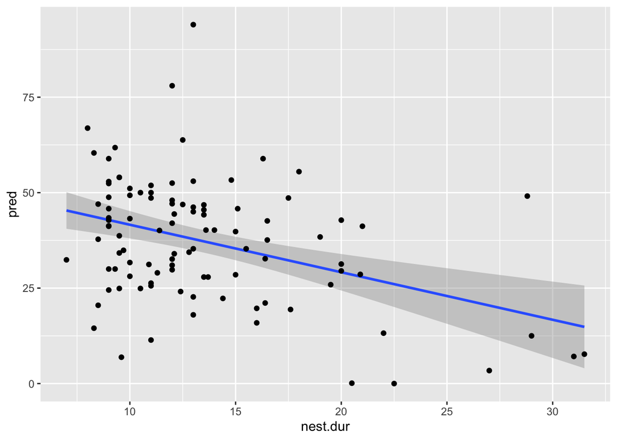

```r
qplot(y = pred,
      x = nest.dur,
      data = martin,
geom = c("smooth","point"),
method = "lm")
```

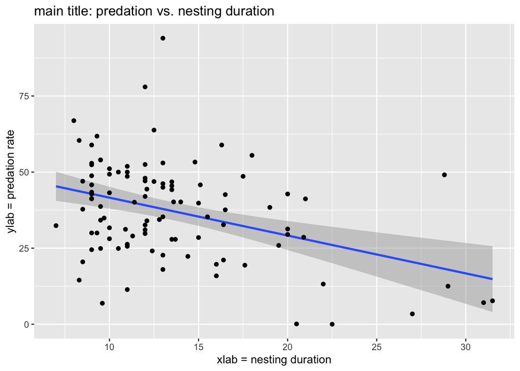

```r
qplot(y = pred, x = nest.dur, data = martin,
geom = c("smooth","point"),
#se = FALSE,
method = "lm",
xlab = "xlab = nesting duration",
ylab = "ylab = predation rate",
main = "main title: predation vs. nesting duration")
```